# act_report

"We_rate_dogs" is a highly popular twitter account where users share cute dog photos and give them a core. What is unique about this account is that most of the ratings, if not all, are higher than the maximum score 10. This reflects people's affection of "mankind's best friend".

In this blog post, I'll perform analysis on the cleaned dataset gathered from over 2,000 "Weratedogs" tweets to answer the following questions: 1) What is the distribution of the ratings? 2) Is there rating difference among dog types? 3) I'd assume the number of retweets and that of favorites are strongly related. Because the more an image is marked as "favorite", the more likely people will retweet it. We'll see if this is true from the data.

```python
#import libraries
import pandas as pd
import numpy as np
import seaborn as sns
import matplotlib.pyplot as plt
%matplotlib inline
```

```python
#import cleaned dataset
df = pd.read_csv('twitter_archive_master.csv')
```

### What is the distribution of ratings?

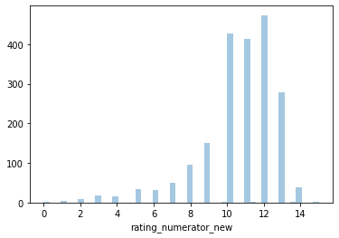

```python
#plot histogram of ratings
sns.distplot(df['rating_numerator_new'], kde = False,hist = True)
```

```python
#take a look at the quartiles
df['rating_numerator_new']. describe()
```

```
count    2049.000000
mean       10.598233
std         2.170268
min         0.000000
25%        10.000000
50%        11.000000
75%        12.000000
max        15.000000
Name: rating_numerator_new, dtype: float64
```

As shown by the plot and chart above, the distribution of the ratings is left-skewed. Most of the ratings, as is unique about the account, are greater than 10. As a result, the mean of the ratings is 11 while the standard deviation is 2. Very few ratings are above 13. Half of them falls between 10 and 12 inclusive.

### Is there rating difference among dog types?

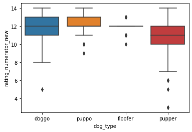

```python
#create box plot to see if there is a rating difference among dog types
sns.boxplot(y = df['rating_numerator_new'],  x = df['dog_type'])
```

It's hard to tell whether there is difference in mean among dog types based purely from the plot above. We'll need to perform statistical analysis to find answer. We'll treat the ratings from each dog type in the dataset as a representative sample of all the ratings from the account. There is limitation to this assumption as the dataset is gathered from a certain time period and could vary from other periods. But this likelihood is quite low so I believe it's still fair to use the data as representative samples.

```python
#Another limitation is the very small number of data points for puppo and floofer compared with doggo and pupper.

df['dog_type'].value_counts()
```

```
pupper     224
doggo       74
puppo       29
floofer     21
Name: dog_type, dtype: int64
```

```python
#import stats libraries
import statsmodels.api as sm
from scipy import stats
from statsmodels.stats.multicomp import pairwise_tukeyhsd
from statsmodels.stats.multicomp import MultiComparison
```

```python
#perform ANOVA analysis
stats.f_oneway(df['rating_numerator_new'][df['dog_type'] == 'doggo'], \
               df['rating_numerator_new'][df['dog_type'] == 'puppo'], \
               df['rating_numerator_new'][df['dog_type'] == 'floofer'],\
               df['rating_numerator_new'][df['dog_type'] == 'pupper'])
```

```
F_onewayResult(statistic=13.508420388648144, pvalue=2.3649783589463622e-08)
```

```python
#From the result above we can see that there is indeed difference between at least two of the dog types.
#Then we can calculate tukey's HSD to see which two (or more) groups have difference in mean rating.

mc = MultiComparison(df['rating_numerator_new'], df['dog_type'], group_order=['doggo','floofer','puppo','pupper'])
result = mc.tukeyhsd()
```

```python
#see the results
print(mc)
print(result)
```

```
<statsmodels.sandbox.stats.multicomp.MultiComparison object at 0x000001FCE30C1AC8>
 Multiple Comparison of Means - Tukey HSD, FWER=0.05
======================================================
 group1  group2 meandiff p-adj   lower   upper  reject
------------------------------------------------------
  doggo floofer    0.195    0.9 -0.8888  1.2787  False
  doggo   puppo   0.4758 0.5678 -0.4845   1.436  False
  doggo  pupper  -1.0405  0.001 -1.6282 -0.4528   True
floofer   puppo   0.2808    0.9 -0.9752  1.5367  False
floofer  pupper  -1.2354 0.0085 -2.2358 -0.2351   True
  puppo  pupper  -1.5162  0.001 -2.3813 -0.6512   True
------------------------------------------------------
```

From the results above, we can see that the mean rating for pupper is lower than both doggo, floofer and puppo. In other words, among the four types, pupper has the lowest average rating.

### Nubmer of retweets and favorites

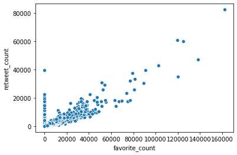

```python
#draw scatterplot
sns.scatterplot(x = df["favorite_count"], y = df["retweet_count"])
```

From the chart above, we can see that there is a strong linear relationship between number of favorites and that of retweets. We can then build a linear regression model using number of favorites to predict retweet.

```python
#create intercept
df['intercept'] = 1
```

```python
#build linear regression model
lm = sm.OLS(df['retweet_count'], df[['intercept', 'favorite_count']])
results = lm.fit()
results.summary()
```

OLS Regression Results

| Dep. Variable: | retweet_count | R-squared: | 0.733 |
| --- | --- | --- | --- |
| Model: | OLS | Adj. R-squared: | 0.733 |
| Method: | Least Squares | F-statistic: | 5627. |
| Date: | Wed, 08 Jan 2020 | Prob (F-statistic): | 0.00 |
| Time: | 14:00:43 | Log-Likelihood: | -18926. |
| No. Observations: | 2049 | AIC: | 3.786e+04 |
| Df Residuals: | 2047 | BIC: | 3.787e+04 |
| Df Model: | 1 |  |  |
| Covariance Type: | nonrobust |  |  |

|  | coef | std err | t | P>\|t\| | [0.025 | 0.975] |
| --- | --- | --- | --- | --- | --- | --- |
| intercept | 26.7766 | 65.888 | 0.406 | 0.684 | -102.439 | 155.992 |
| favorite_count | 0.3293 | 0.004 | 75.015 | 0.000 | 0.321 | 0.338 |

| Omnibus: | 2344.034 | Durbin-Watson: | 1.584 |
| --- | --- | --- | --- |
| Prob(Omnibus): | 0.000 | Jarque-Bera (JB): | 307177.364 |
| Skew: | 5.699 | Prob(JB): | 0.00 |
| Kurtosis: | 61.890 | Cond. No. | 1.80e+04 |

Warnings:  
[1] Standard Errors assume that the covariance matrix of the errors is correctly specified.  
[2] The condition number is large, 1.8e+04. This might indicate that there are  
strong multicollinearity or other numerical problems.

The regression coefficient for favorite_count is significant. So the correlation between favorite_count and retweet_count is significant. (no surprise here!) We can be reasonably sure that an increase in one favorite is associated a growth of 0.3 retweet.

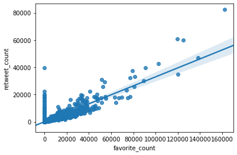

```python
#see the regression line in scatter plot
sns.regplot(x = df["favorite_count"], y = df["retweet_count"])
```

The above plot show the regression line and the confidence interval for retweet_count given each favorite_count.

### Summary

In this blog post about "Weratedogs" Twitter account, I analyzed data to answer three questions and employed visualization to demonstrate the relationships of interest. Briefly, I've found that: 1) The distribution of the dog ratings is left-skewed. Most of the ratings, as is unique about the account, are greater than 10. As a result, the mean of the ratings is 11 while the standard deviation is 2. Very few ratings are above 13. Half of them falls between 10 and 12 inclusive. 2) Pupper has the lowest average rating among the four dog types, namely "puppo", "pupper", "floofer" and "doggo". On the other hand, there is no significant difference in average ratings among the remaining three types. 3) There is strong linear relationship between number of favorites and retweets. Specifically, as number of favorites increases by 1, the number of retweets will grow by 0.3.